# R Notebook

### read.csv

The utils package, which is automatically loaded in your R session on startup, can import CSV files with the read.csv() function.

In this exercise, you’ll be working with swimming_pools.csv; it contains data on swimming pools in Brisbane, Australia (Source: data.gov.au). The file contains the column names in the first row. It uses a comma to separate values within rows.

Type dir() in the console to list the files in your working directory. You’ll see that it contains swimming_pools.csv, so you can start straight away.

```r
# Import swimming_pools.csv: pools
pools <- read.csv("./data/swimming_pools.csv")


# Print the structure of pools
str(pools)
```

### stringsAsFactors

With stringsAsFactors, you can tell R whether it should convert strings in the flat file to factors.

You’ll again be working with the swimming_pools.csv file. It contains two columns (Name and Address), which shouldn’t be factors.

```r
str(pools)
```

```
'data.frame':   20 obs. of  4 variables:
 $ Name     : chr  "Acacia Ridge Leisure Centre" "Bellbowrie Pool" "Carole Park" "Centenary Pool (inner City)" ...
 $ Address  : chr  "1391 Beaudesert Road, Acacia Ridge" "Sugarwood Street, Bellbowrie" "Cnr Boundary Road and Waterford Road Wacol" "400 Gregory Terrace, Spring Hill" ...
 $ Latitude : num  -27.6 -27.6 -27.6 -27.5 -27.4 ...
 $ Longitude: num  153 153 153 153 153 ...
```

### read.delim

Aside from .csv files, there are also the .txt files which are basically text files. You can import these functions with read.delim(). By default, it sets the sep argument to “” (fields in a record are delimited by tabs) and the header argument to TRUE (the first row contains the field names).

In this exercise, you will import hotdogs.txt, containing information on sodium and calorie levels in different hotdogs (Source: UCLA). The dataset has 3 variables, but the variable names are not available in the first line of the file. The file uses tabs as field separators.

```r
# Import hotdogs.txt: hotdogs
hotdogs <- read.delim("./data/hotdogs.txt", header = FALSE)

# Summarize hotdogs
summary(hotdogs)
```

[output not shown]

### read.table

If you’re dealing with more exotic flat file formats, you’ll want to use read.table(). It’s the most basic importing function; you can specify tons of different arguments in this function. Unlike read.csv() and read.delim(), the header argument defaults to FALSE and the sep argument is “” by default.

Up to you again! The data is still hotdogs.txt. It has no column names in the first row, and the field separators are tabs. This time, though, the file is in the data folder inside your current working directory. A variable path with the location of this file is already coded for you.

```r
# Path to the hotdogs.txt file: path
path <- file.path("./data", "hotdogs2.txt")

# Import the hotdogs.txt file: hotdogs
hotdogs2 <- read.table(path,
                      sep = "\t",
                      col.names = c("type", "calories", "sodium"))

# Call head() on hotdogs
head(hotdogs2)
```

[output not shown]

### Arguments

Lily and Tom are having an argument because they want to share a hot dog but they can’t seem to agree on which one to choose. After some time, they simply decide that they will have one each. Lily wants to have the one with the fewest calories while Tom wants to have the one with the most sodium.

Next to calories and sodium, the hotdogs have one more variable: type. This can be one of three things: Beef, Meat, or Poultry, so a categorical variable: a factor is fine.

```r
# Finish the read.delim() call
hotdogs <- read.delim("./data/hotdogs.txt", header = FALSE, col.names = c("type", "calories", "sodium"))

# Select the hot dog with the least calories: lily
lily <- hotdogs[which.min(hotdogs$calories), ]

# Select the observation with the most sodium: tom
tom <- hotdogs[which.max(hotdogs$sodium), ]

# Print lily and tom
lily
tom
```

[output not shown]

### Column classes

Next to column names, you can also specify the column types or column classes of the resulting data frame. You can do this by setting the colClasses argument to a vector of strings representing classes:

read.delim(“my_file.txt”, colClasses = c(“character”, “numeric”, “logical”)) This approach can be useful if you have some columns that should be factors and others that should be characters. You don’t have to bother with stringsAsFactors anymore; just state for each column what the class should be.

If a column is set to “NULL” in the colClasses vector, this column will be skipped and will not be loaded into the data frame.

```r
# Previous call to import hotdogs.txt
hotdogs <- read.delim("./data/hotdogs.txt", header = FALSE, col.names = c("type", "calories", "sodium"))

# Display structure of hotdogs
str(hotdogs)

# Edit the colClasses argument to import the data correctly: hotdogs2
hotdogs2 <- read.delim("./data/hotdogs.txt", header = FALSE,
                       col.names = c("type", "calories", "sodium"),
                       colClasses = c("factor", "NULL", "numeric"))


# Display structure of hotdogs2
str(hotdogs2)
```

[output not shown]

## The better way

### read_csv

CSV files can be imported with read_csv(). It’s a wrapper function around read_delim() that handles all the details for you. For example, it will assume that the first row contains the column names.

The dataset you’ll be working with here is potatoes.csv. It gives information on the impact of storage period and cooking on potatoes’ flavor. It uses commas to delimit fields in a record, and contains column names in the first row. The file is available in your workspace. Remember that you can inspect your workspace with dir().

```r
# Load the readr package
library(readr)

# Import potatoes.csv with read_csv(): potatoes
potatoes <- read_csv("./data/potatoes.csv")
```

### read_tsv

Where you use read_csv() to easily read in CSV files, you use read_tsv() to easily read in TSV files. TSV is short for tab-seperated values.

This time, the potatoes data comes in the form of a tab-separated values file; potatoes.txt is available in your workspace. In contrast to potatoes.csv, this file does not contain columns names in the first row, though.

There’s a vector properties that you can use to specify these column names manually.

```r
# readr is already loaded

# Column names
properties <- c("area", "temp", "size", "storage", "method",
                "texture", "flavor", "moistness")

# Import potatoes.txt: potatoes
potatoes <- read_tsv("./data/potatoes.txt", col_names = properties)

# Call head() on potatoes
head(potatoes)
```

[output not shown]

### read_delim

Just as read.table() was the main utils function, read_delim() is the main readr function.

read_delim() takes two mandatory arguments:

file: the file that contains the data delim: the character that separates the values in the data file You’ll again be working potatoes.txt; the file uses tabs (“”) to delimit values and does not contain column names in its first line. It’s available in your working directory so you can start right away. As before, the vector properties is available to set the col_names.

```r
# readr is already loaded

# Column names
properties <- c("area", "temp", "size", "storage", "method",
                "texture", "flavor", "moistness")

# Import potatoes.txt using read_delim(): potatoes
potatoes <- read_delim("./data/potatoes.txt", delim = "\t", col_names = properties)

# Print out potatoes
potatoes
```

[output not shown]

### skip and n_max

Through skip and n_max you can control which part of your flat file you’re actually importing into R.

skip specifies the number of lines you’re ignoring in the flat file before actually starting to import data. n_max specifies the number of lines you’re actually import. Say for example you have a CSV file with 20 lines, and set skip = 2 and n_max = 3, you’re only reading in lines 3, 4 and 5 of the file.

Watch out: Once you skip some lines, you also skip the first line that can contain column names!

potatoes.txt, a flat file with tab-delimited records and without column names, is available in your workspace.

| area | temp | size | storage | method | texture | flavor | moistness |
| --- | --- | --- | --- | --- | --- | --- | --- |
| 1 | 1 | 1 | 2 | 3 | 3.0 | 3.0 | 2.9 |
| 1 | 1 | 1 | 2 | 4 | 2.2 | 3.2 | 2.5 |
| 1 | 1 | 1 | 2 | 5 | 2.0 | 2.8 | 1.9 |
| 1 | 1 | 1 | 3 | 1 | 1.8 | 2.6 | 1.5 |
| 1 | 1 | 1 | 3 | 2 | 2.0 | 2.8 | 1.9 |

### col_types

You can also specify which types the columns in your imported data frame should have. You can do this with col_types. If set to NULL, the default, functions from the readr package will try to find the correct types themselves. You can manually set the types with a string, where each character denotes the class of the column: character, double, integer and logical. _ skips the column as a whole.

potatoes.txt, a flat file with tab-delimited records and without column names, is again available in your workspace.

```r
str(potatoes_char)
```

```
Classes ‘tbl_df’, ‘tbl’ and 'data.frame':   159 obs. of  8 variables:
 $ area     : chr  "1" "1" "1" "1" ...
 $ temp     : chr  "1" "1" "1" "1" ...
 $ size     : chr  "1" "1" "1" "1" ...
 $ storage  : chr  "1" "1" "1" "1" ...
 $ method   : chr  "2" "3" "4" "5" ...
 $ texture  : chr  "2.3" "2.5" "2.1" "1.9" ...
 $ flavor   : chr  "2.5" "2.8" "2.9" "2.8" ...
 $ moistness: chr  "2.6" "2.8" "2.4" "2.2" ...
 - attr(*, "spec")=List of 2
  ..$ cols   :List of 8
  .. ..$ area     : list()
  .. .. ..- attr(*, "class")= chr  "collector_character" "collector"
  .. ..$ temp     : list()
  .. .. ..- attr(*, "class")= chr  "collector_character" "collector"
  .. ..$ size     : list()
  .. .. ..- attr(*, "class")= chr  "collector_character" "collector"
  .. ..$ storage  : list()
  .. .. ..- attr(*, "class")= chr  "collector_character" "collector"
  .. ..$ method   : list()
  .. .. ..- attr(*, "class")= chr  "collector_character" "collector"
  .. ..$ texture  : list()
  .. .. ..- attr(*, "class")= chr  "collector_character" "collector"
  .. ..$ flavor   : list()
  .. .. ..- attr(*, "class")= chr  "collector_character" "collector"
  .. ..$ moistness: list()
  .. .. ..- attr(*, "class")= chr  "collector_character" "collector"
  ..$ default: list()
  .. ..- attr(*, "class")= chr  "collector_guess" "collector"
  ..- attr(*, "class")= chr "col_spec"
```

### col_types with collectors

Another way of setting the types of the imported columns is using collectors. Collector functions can be passed in a list() to the col_types argument of read_ functions to tell them how to interpret values in a column.

For a complete list of collector functions, you can take a look at the collector documentation. For this exercise you will need two collector functions:

col_integer(): the column should be interpreted as an integer. col_factor(levels, ordered = FALSE): the column should be interpreted as a factor with levels. In this exercise, you will work with hotdogs.txt, which is a tab-delimited file without column names in the first row.

```r
summary(hotdogs_factor)
```

```
      type       calories         sodium
 Beef   :20   Min.   : 86.0   Min.   :144.0
 Meat   :17   1st Qu.:132.0   1st Qu.:362.5
 Poultry:17   Median :145.0   Median :405.0
              Mean   :145.4   Mean   :424.8
              3rd Qu.:172.8   3rd Qu.:503.5
              Max.   :195.0   Max.   :645.0
```

## An Even Better Way

### fread

You still remember how to use read.table(), right? Well, fread() is a function that does the same job with very similar arguments. It is extremely easy to use and blazingly fast! Often, simply specifying the path to the file is enough to successfully import your data.

Don’t take our word for it, try it yourself! You’ll be working with the potatoes.csv file, that’s available in your workspace. Fields are delimited by commas, and the first line contains the column names.

| area | temp | size | storage | method | texture | flavor | moistness |
| --- | --- | --- | --- | --- | --- | --- | --- |
| 1 | 1 | 1 | 1 | 1 | 2.9 | 3.2 | 3.0 |
| 1 | 1 | 1 | 1 | 2 | 2.3 | 2.5 | 2.6 |
| 1 | 1 | 1 | 1 | 3 | 2.5 | 2.8 | 2.8 |
| 1 | 1 | 1 | 1 | 4 | 2.1 | 2.9 | 2.4 |
| 1 | 1 | 1 | 1 | 5 | 1.9 | 2.8 | 2.2 |
| 1 | 1 | 1 | 2 | 1 | 1.8 | 3.0 | 1.7 |
| 1 | 1 | 1 | 2 | 2 | 2.6 | 3.1 | 2.4 |
| 1 | 1 | 1 | 2 | 3 | 3.0 | 3.0 | 2.9 |
| 1 | 1 | 1 | 2 | 4 | 2.2 | 3.2 | 2.5 |
| 1 | 1 | 1 | 2 | 5 | 2.0 | 2.8 | 1.9 |

[output cut: 150 more lines]

### fread: more advanced use

Now that you know the basics about fread(), you should know about two arguments of the function: drop and select, to drop or select variables of interest.

Suppose you have a dataset that contains 5 variables and you want to keep the first and fifth variable, named “a” and “e”. The following options will all do the trick:

fread(“path/to/file.txt”, drop = 2:4) fread(“path/to/file.txt”, select = c(1, 5)) fread(“path/to/file.txt”, drop = c(“b”, “c”, “d”) fread(“path/to/file.txt”, select = c(“a”, “e”)) Let’s stick with potatoes since we’re particularly fond of them here at DataCamp. The data is again available in the file potatoes.csv, containing comma-separated records.

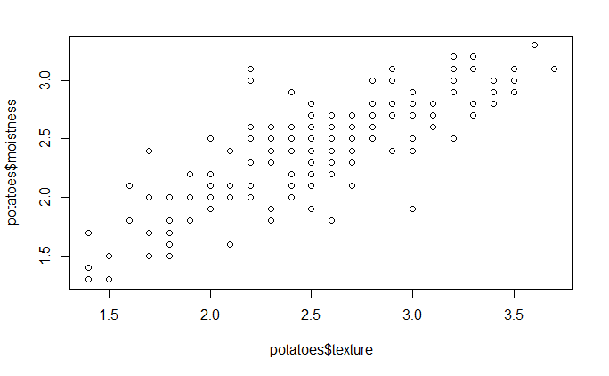

### Dedicated classes

You might have noticed that the fread() function produces data frames that look slightly different when you print them out. That’s because another class named data.table is assigned to the resulting data frames. The printout of such data.table objects is different. Does something similar happen with the data frames generated by readr?

In your current working directory, we prepared the potatoes.csv file. The packages data.table and readr are both loaded, so you can experiment straight away.

Which of the following statements is true?

```r
class(read_tsv("./data/potatoes.csv"))
```

```
[1] "tbl_df"     "tbl"        "data.frame"
```

The class of the result of fread() is both data.table and data.frame. read_tsv() creates an object with three classes: tbl_df, tbl and data.frame.